# Probabilidad

# Introducciòn

La probabilidad es un método por el cual se obtiene la frecuencia de un acontecimiento determinado mediante la realización de un experimento aleatorio, del que se conocen todos los resultados posibles, bajo condiciones suficientemente estables.

La teoría de la probabilidad se usa extensamente en áreas como la estadìstica, la física, la matemática, las ciencias y la filosofía para sacar conclusiones sobre la probabilidad discreta de sucesos potenciales y la mecánica subyacente discreta de sistemas complejos, por lo tanto es la rama de las matemáticas que estudia, mide o determina a los experimentos o fenómenos aleatorios.

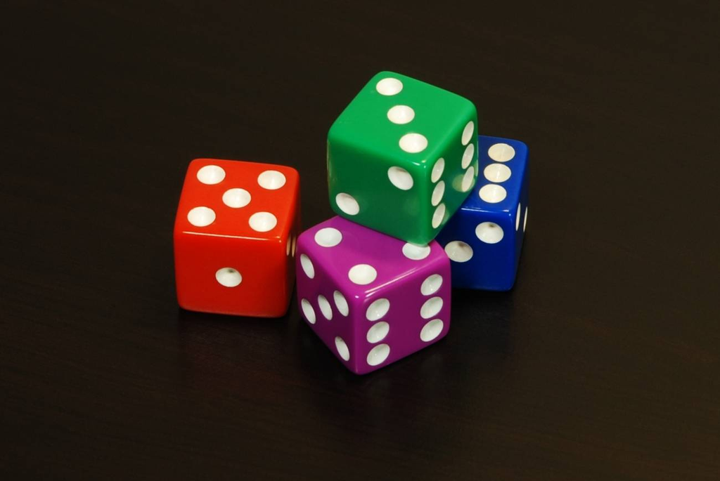

# Definiciones

## Fenòmeno aleatorio

Un fenòmeno aleatorio es un experimento o proceso cuyo resultado no puede preverse con certeza antes de realizarse, pero cuyos posibles resultados estàn determinados ypueden describirse mediante un espacio muestral.

## Espacio muestral

Un espacio muestral es el conjunto formado por todos los resultados posibles de un fenòmeno aleatorio, y se denota generalmente por la letra griega Ω.

## Evento

Un evento en probabilidad es cualquier subconjunto del espacio muestral Ω, es decir, un conjunto de resultados posibles de un fenòmeno aleatorio

# Teoremas

## Regla de la adiciòn

La regla de adiciòn en probabilidad establece que:

**La probabilidad de que ocurra al menos uno de dos eventos A o B es igual a la suma de sus probabilidades individuales, menos la probabilidad de que ocurran ambos simultàneamente.**

En fòrmula:

$$(A∪B)=P (A)+P(B)-P(A∩B)$$
Si los eventos son mutuamente excluyentes (no pueden ocurrir al mismo tiempo), la fòrmula se simplifica a:

$$P(A∪B)=P(A)+P(B)$$

## Reglas de la multiplicaciòn

La regla de la multiplicación, también conocida como regla del producto, se utiliza para encontrar la probabilidad conjunta de que ocurran dos eventos La forma general de la regla es: Para eventos independientes:

$$P(A∩B)=P(A)×P(B)$$

Esto significa que la probabilidad de que ocurran ambos eventos es el producto de sus probabilidades individuales, ya que la ocurrencia de uno no afecta al otro.

Para eventos dependientes:
$$P(A∩B)=P(A)×P(B∣A)$$

Aquí,P(B∣A) es la probabilidad de que ocurra el evento B dado que ya ha ocurrido el evento A. Esto indica que la ocurrencia de A afecta la probabilidad de B.

## Teorema de Bayes

El Teorema de Bayes, formulado por el matemático inglés Thomas Bayes en el siglo XVIII, establece una relación entre la probabilidad de un evento A dado que ha ocurrido otro evento B.Este teorema es crucial para calcular probabilidades condicionales y se expresa matemáticamente como:

$$P(A \mid B) = \frac{P(B \mid A) \cdot
P(A)}{P(B)}$$
Donde:

- P(A∣B) es la probabilidad de A dado B (probabilidad a posterori).
- P(B∣A) es la probabilidad de B dado A.
- P(A) es la probabilidad de A (probabilidad a priori).
- P(B) es la probabilidad de B.